# Problemas de correlación

Bioestadística

Noviembre 2026

En estos problemas **no hace falta calcular las correlaciones desde cero**: el objetivo es saber **leer e interpretar** los resultados y **reflexionar** sobre ellos. Los cálculos se hacen a mano (con calculadora). Recuerda:

- **Coeficiente de correlación de Pearson** ( $r$ ): mide la fuerza y la dirección de una relación **lineal**, entre −1 y 1. El signo indica la dirección; el valor absoluto, la fuerza
- **Coeficiente de Spearman** ( $r_s$ ): es la correlación de Pearson calculada sobre los **rangos**. Sirve para relaciones **monótonas** no lineales, datos ordinales, muestras pequeñas o con valores extremos. Sin empates: $r_s = 1 - \dfrac{6\sum d_i^2}{n(n^2-1)}$, con $d_i$ la diferencia de rangos
- **Test de la correlación**: $H_0: \rho = 0$. Estadístico $t = \dfrac{r\sqrt{n-2}}{\sqrt{1-r^2}}$, con $gl = n - 2$. Rechazamos $H_0$ si $|t_{obs}| > t_{crit}$
- $r^2$: proporción de la variabilidad de una variable que se explica por la otra
- **Correlación no implica causalidad**, y una correlación **significativa** no tiene por qué ser **fuerte**

**Tabla de valores críticos de t** (dos colas, α = 0.05):

| $gl$ | 3 | 6 | 9 | 10 | 66 | 340 |
| --- | --- | --- | --- | --- | --- | --- |
| $t_{crit}$ | 3.182 | 2.447 | 2.262 | 2.228 | 1.997 | 1.967 |

## 🐧 Problema 1 - El pico de los pingüinos

Entre 2007 y 2009, Kristen Gorman midió el pico de **342 pingüinos** de tres especies (Adelia, barbijo y papúa) en el archipiélago Palmer (Antártida). Queremos saber si la **longitud** y la **profundidad** (altura) del pico están relacionadas.

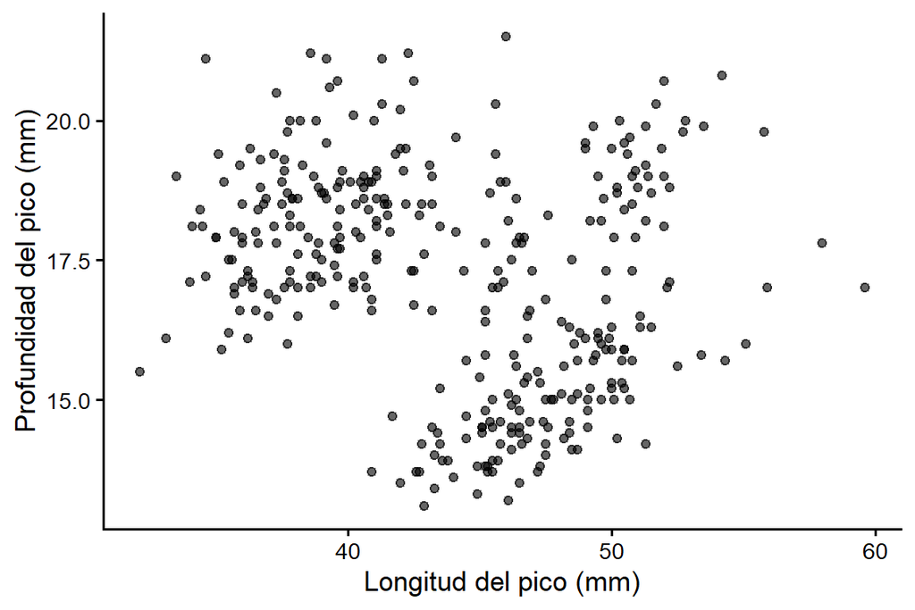

Con todos los pingüinos juntos, el coeficiente de correlación de Pearson es **r = −0.235**.

### a) Escribe las hipótesis nula y alternativa del test de correlación.

### b) Interpreta el signo y la fuerza de la correlación. Calcula $r^2$ e interprétalo.

### c) Calcula el estadístico t y decide si la correlación es significativa (α = 0.05).

### d) Ahora separamos los pingüinos por especie. ¿Qué ocurre? Calcula el estadístico t para el pingüino barbijo y decide si es significativo. ¿Cómo explicas que la correlación cambie de signo?

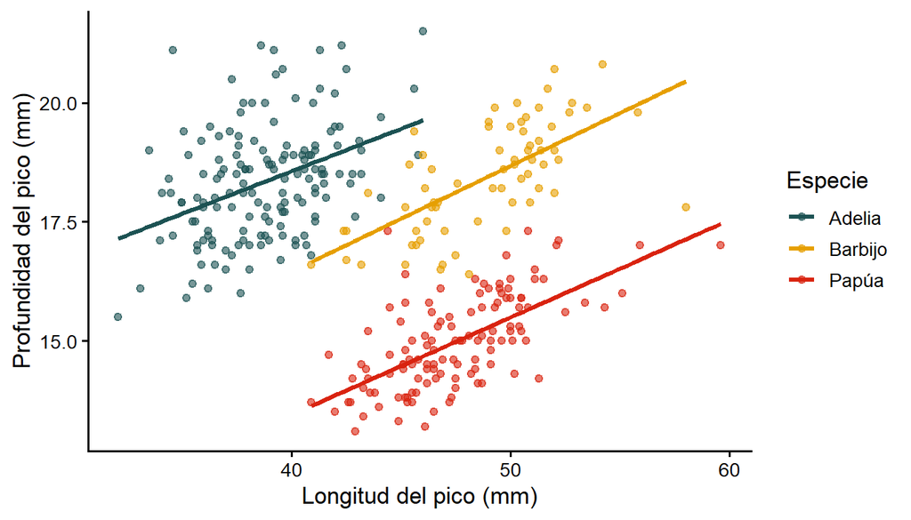

| Especie | *n* | *r* |
| --- | --- | --- |
| Adelia | 151 | 0.391 |
| Barbijo | 68 | 0.654 |
| Papúa | 123 | 0.643 |

### e) ¿Podemos concluir que un pico más largo **provoca** un pico más profundo?

**Respuestas**

| Apartado | Resultado |
| --- | --- |
| (a) | $H_0$: $\rho = 0$ (no hay correlación lineal); $H_A$: $\rho \neq 0$ |
| (b) | Negativa y débil; $r^2$ = 0.055: la longitud explica solo el 5.5% de la variabilidad de la profundidad |
| (c) | $t$ = −4.46; $\|t\|$ > 1.967 → correlación significativa |
| (d) | Dentro de cada especie la correlación es **positiva** y moderada. Barbijo: $t$ = 7.01 > 1.997, significativa. La especie es una variable de confusión (paradoja de Simpson) |
| (e) | No: correlación no implica causalidad. Ambas medidas dependen, por ejemplo, del tamaño del individuo |

## 🧪 Problema 2 - ¿Pearson o Spearman?

Treloar (1974) midió la **velocidad inicial** de una reacción enzimática (en cuentas/min²) a distintas **concentraciones de sustrato** (en ppm), en células tratadas con puromicina:

| conc | 0.02 | 0.02 | 0.06 | 0.06 | 0.11 | 0.11 | 0.22 | 0.22 | 0.56 | 0.56 | 1.1 | 1.1 |
| --- | --- | --- | --- | --- | --- | --- | --- | --- | --- | --- | --- | --- |
| rate | 76.00 | 47.00 | 97.00 | 107.00 | 123.00 | 139.00 | 159.00 | 152.00 | 191.00 | 201.00 | 207.0 | 200.0 |

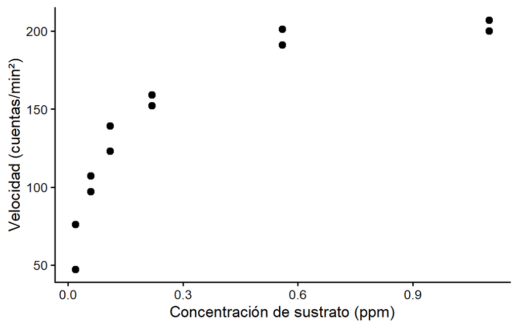

### a) Describe la relación entre las dos variables a partir del gráfico.

### b) La correlación de Pearson es **r = 0.831** (p = 0.0008) y la de Spearman, **ρ = 0.975** (p < 0.001). ¿Por qué son tan diferentes? ¿Cuál es más adecuada aquí?

### c) Comprueba con el estadístico t que la correlación de Pearson es significativa (α = 0.05).

### d) Un compañero dice: “r = 0.83 es una correlación lineal fuerte, así que puedo ajustar una recta `lm(rate ~ conc)` sin problemas”. ¿Estás de acuerdo?

**Respuestas**

| Apartado | Resultado |
| --- | --- |
| (a) | Positiva y monótona, pero **no lineal**: la velocidad sube rápido y luego se satura (cinética de Michaelis-Menten) |
| (b) | Pearson mide relación **lineal**; Spearman, relación **monótona**. Aquí es más adecuada Spearman |
| (c) | $t$ = 4.72 > 2.228 ($gl$ = 10) → significativa |
| (d) | No: un $r$ alto no garantiza que la relación sea lineal. Hay que mirar siempre el gráfico; transformar (p. ej. `log(conc)`) o usar un modelo no lineal |

## 📈 Problema 3 - Cuatro conjuntos de datos con la misma correlación

El estadístico Francis Anscombe (1973) construyó cuatro conjuntos de datos de 11 observaciones cada uno. Al calcular la correlación y la recta de regresión, los cuatro dan **prácticamente el mismo resultado**:

| Conjunto | $r$ | Recta de regresión |
| --- | --- | --- |
| I | 0.816 | $\hat{y} = 3.0 + 0.5\,x$ |
| II | 0.816 | $\hat{y} = 3.0 + 0.5\,x$ |
| III | 0.816 | $\hat{y} = 3.0 + 0.5\,x$ |
| IV | 0.817 | $\hat{y} = 3.0 + 0.5\,x$ |

### a) Calcula el estadístico t para $r$ = 0.816 y decide si la correlación es significativa (α = 0.05).

### b) Ahora mira los datos. ¿En qué conjuntos tiene sentido resumir la relación con el coeficiente de Pearson? Describe qué ocurre en cada uno.

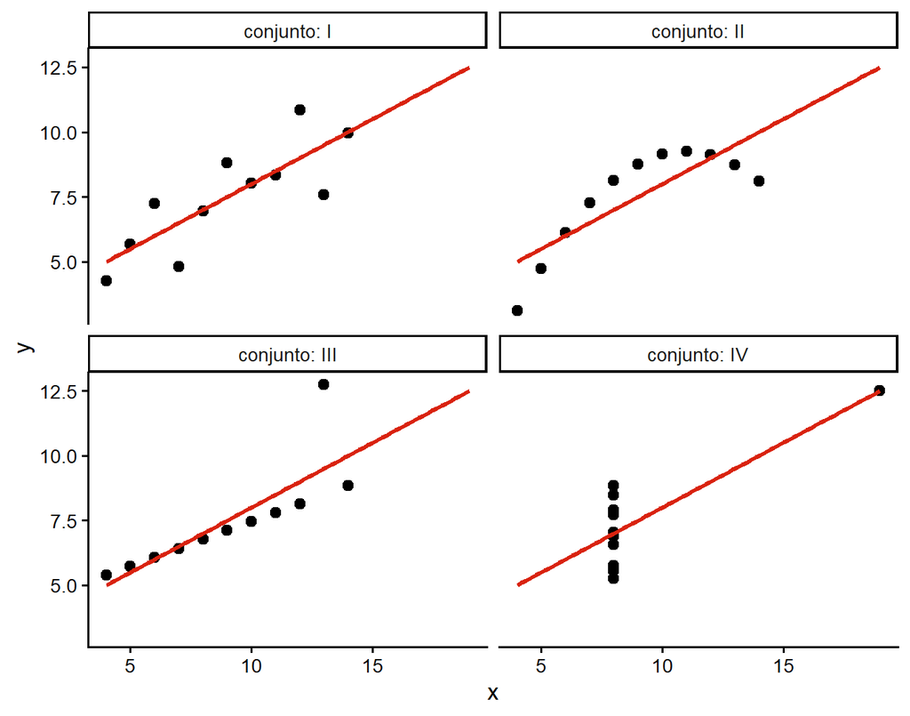

### c) En el conjunto III, la correlación de Spearman es $r_s$ = 0.991, mucho mayor que la de Pearson. ¿Por qué?

### d) ¿Qué lección sacas de este problema?

**Respuestas**

| Apartado | Resultado |
| --- | --- |
| (a) | $t$ = 4.24 > 2.262 ($gl$ = 9) → significativa en los cuatro conjuntos |
| (b) | Solo en el I (relación lineal con dispersión). II: relación **curva**; III: lineal perfecta salvo un **valor atípico**; IV: no hay relación, la correlación la crea **un único punto** extremo |
| (c) | Spearman usa los rangos: el valor atípico pasa a ser simplemente el valor más alto y pierde su peso |
| (d) | Los mismos números pueden venir de datos muy distintos: hay que **representar siempre los datos** antes de calcular |

## 🪰 Problema 4 - Altitud y tamaño del ala

Se midió el tamaño medio del ala (en mm) de *Drosophila melanogaster* en 8 poblaciones situadas a distintas altitudes (datos ilustrativos):

| Población | 1 | 2 | 3 | 4 | 5 | 6 | 7 | 8 |
| --- | --- | --- | --- | --- | --- | --- | --- | --- |
| Altitud (m) | 120 | 450 | 800 | 1100 | 1500 | 1900 | 2300 | 2700 |
| Ala (mm) | 2.10 | 2.18 | 2.15 | 2.30 | 2.26 | 2.41 | 2.39 | 2.52 |

### a) Con solo 8 poblaciones, ¿por qué puede ser preferible el coeficiente de Spearman al de Pearson?

### b) Calcula a mano el coeficiente de Spearman: asigna los rangos, calcula las diferencias $d_i$ y $\sum d_i^2$.

### c) Esta es la salida de `R`. Comprueba tu resultado e interpreta el p-valor.

```r
altitud <- c(120, 450, 800, 1100, 1500, 1900, 2300, 2700)
ala     <- c(2.10, 2.18, 2.15, 2.30, 2.26, 2.41, 2.39, 2.52)
cor.test(altitud, ala, method = "spearman")
```

```
    Spearman's rank correlation rho

data:  altitud and ala
S = 6, p-value = 0.002232
alternative hypothesis: true rho is not equal to 0
sample estimates:
      rho
0.9285714
```

### d) ¿Podemos concluir que vivir a más altitud **provoca** alas más grandes? ¿Qué otra variable podría explicar la relación?

**Respuestas**

| Apartado | Resultado |
| --- | --- |
| (a) | Con $n$ = 8 no podemos comprobar bien la normalidad, y un solo valor extremo pesaría mucho. Spearman no requiere normalidad |
| (b) | Rangos del ala: 1, 3, 2, 5, 4, 7, 6, 8; $d_i$: 0, −1, 1, −1, 1, −1, 1, 0; $\sum d_i^2$ = 6; $r_s$ = 1 − 36/504 = 0.929 |
| (c) | $r_s$ = 0.929, p = 0.002 < 0.05 → correlación positiva, muy alta y significativa |
| (d) | No: es un estudio observacional. La **temperatura** (más baja a más altitud) podría ser la causa |

## 🐧 Problema 5 - Una matriz de correlaciones

Con los mismos pingüinos del Problema 1, calculamos la correlación entre las cuatro medidas morfológicas: longitud del pico (`bill_len`), profundidad del pico (`bill_dep`), longitud de la aleta (`flipper_len`) y masa corporal (`body_mass`).

```r
morfo <- na.omit(penguins[, c("bill_len", "bill_dep", "flipper_len", "body_mass")])
nrow(morfo)
```

```
[1] 342
```

```r
round(cor(morfo), 2)
```

```
            bill_len bill_dep flipper_len body_mass
bill_len        1.00    -0.24        0.66      0.60
bill_dep       -0.24     1.00       -0.58     -0.47
flipper_len     0.66    -0.58        1.00      0.87
body_mass       0.60    -0.47        0.87      1.00
```

### a) ¿Por qué la diagonal vale 1? ¿Por qué la matriz es simétrica?

### b) ¿Qué par de variables tiene la correlación más fuerte? Interprétala y calcula qué porcentaje de la variabilidad de la masa explica la aleta.

### c) La profundidad del pico tiene correlaciones **negativas** con las demás medidas. ¿Significa que los pingüinos con picos más profundos son más pequeños? (Pista: recuerda el Problema 1.)

### d) Queremos predecir la masa corporal con una regresión múltiple que incluya la aleta y la longitud del pico. ¿Habrá problemas de multicolinealidad? (Con dos variables independientes, $VIF = \dfrac{1}{1 - r^2}$, donde $r$ es la correlación entre ellas.)

**Respuestas**

| Apartado | Resultado |
| --- | --- |
| (a) | Cada variable está perfectamente correlacionada consigo misma ($r$ = 1). La correlación es simétrica: `cor(x, y)` = `cor(y, x)` |
| (b) | Aleta y masa: $r$ = 0.87, positiva y muy alta. $r^2$ = 0.76 → la aleta explica el 76% de la variabilidad de la masa |
| (c) | No necesariamente: mezcla tres especies. Dentro de cada especie, la relación es positiva (paradoja de Simpson) |
| (d) | $r$ = 0.66 → $VIF$ = 1/(1 − 0.44) = 1.77 < 10 → no hay multicolinealidad preocupante |

## 🤔 Problema 6 - Preguntas rápidas

### a) La correlación de Pearson entre dos variables es r = 0. ¿Podemos concluir que no hay ninguna relación entre ellas?

### b) La correlación entre la expresión de dos genes es r = −0.9. ¿Qué porcentaje de la variabilidad de uno explica el otro?

### c) Un estudio encontró una correlación de r = 0.79 entre el consumo de chocolate de un país y su número de premios Nobel por habitante. ¿Comer chocolate hace a la gente más inteligente?

### d) En un estudio con 2000 personas, la correlación entre dos variables es r = 0.12 y el p-valor es menor que 0.001. ¿Es una relación fuerte?

### e) En otro estudio, con solo 5 individuos, se obtiene r = 0.8. Calcula el estadístico t. ¿Es significativa? ¿Significa que no hay relación?

### f) Medimos la longitud de unos peces en centímetros y calculamos su correlación con el peso. Si repetimos el cálculo con la longitud en milímetros, ¿cambia $r$?

**Respuestas**

| Apartado | Resultado |
| --- | --- |
| (a) | No: $r$ solo mide relación **lineal**. Puede haber una relación curva (p. ej. en forma de U) |
| (b) | $r^2$ = 0.81 → el 81% |
| (c) | No: correlación no implica causalidad. Una variable de confusión (la riqueza del país) explica ambas |
| (d) | No: $r^2$ = 0.014, explica solo el 1.4%. Con muestras grandes, correlaciones muy débiles ya son significativas |
| (e) | $t$ = 2.31 < 3.182 ($gl$ = 3) → no significativa. No demuestra que no haya relación: con $n$ = 5 el test tiene muy poca potencia |
| (f) | No: $r$ no tiene unidades y no cambia al multiplicar una variable por una constante positiva |

## 📚 Fuentes

- Gorman, K. B., Williams, T. D. y Fraser, W. R. (2014). Ecological sexual dimorphism and environmental variability within a community of Antarctic penguins (genus *Pygoscelis*). *PLoS ONE*, 9(3), e90081. Disponibles en R (≥ 4.5): `penguins`.
- Treloar, M. A. (1974). *Effects of Puromycin on Galactosyltransferase in Golgi Membranes*. Tesis de máster, Universidad de Toronto. Datos en Bates, D. M. y Watts, D. G. (1988). *Nonlinear Regression Analysis and Its Applications*. Wiley. Disponibles en R: `Puromycin`.
- Anscombe, F. J. (1973). Graphs in statistical analysis. *The American Statistician*, 27(1), 17–21. Disponibles en R: `anscombe`.
- Messerli, F. H. (2012). Chocolate consumption, cognitive function, and Nobel laureates. *The New England Journal of Medicine*, 367, 1562–1564.
- Los datos del Problema 4 son ilustrativos.